# ARIMA modeling

### 16.2.3 Air Passengers: ACF and PACF of ddlx

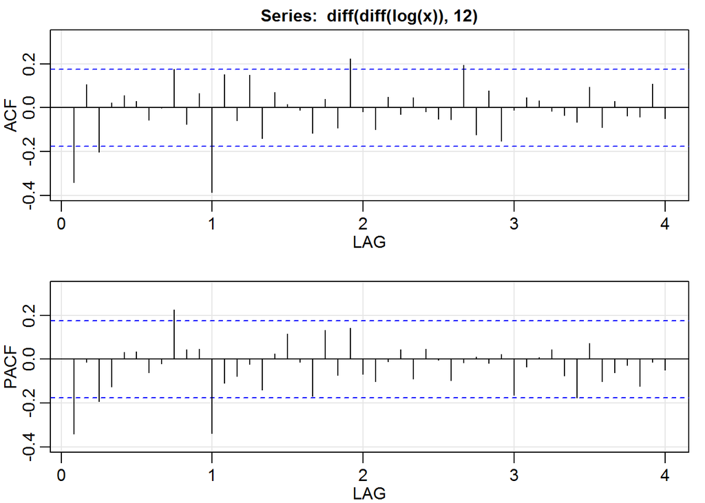

```r
invisible(acf2(diff(diff(log(x)),12)))
```

- Seasonal:
  - ACF cutting off at lag 1S (S = 12)
  - PACF tailing off at lags 1S, 2S, 3S,, & They suggest a Seasonal SMA(1) so capital P = 0 and capital Q = 1
- Non-Seasonal: ACF and PACF both tailing off which sugests an ARMA(1,1) so little p = 1 and and little q = 1

Finally we concluded that
$$SARIMA(1, 1, 1) \times (0, 1, 1)_{12}$$
should be appropriate on the log data.

Fitting $SARIMA(1, 1, 1) \times (0, 1, 1)_{12}$ didn’t find a significant estimate for slope $\phi$ `ar1`

```r
airpass_fit1 <- sarima(log(AirPassengers),
                       p = 1, d = 1, q = 1,
                       P = 0, D = 1, Q = 1,
                       S = 12, details = FALSE)
airpass_fit1$ttable
```

```
     Estimate     SE t.value p.value
ar1    0.1960 0.2475  0.7921  0.4298
ma1   -0.5784 0.2132 -2.7127  0.0076
sma1  -0.5643 0.0747 -7.5544  0.0000
```

Removing a parameter by fitting $SARIMA(0, 1, 1) \times (0, 1, 1)_{12}$ found all significant estimates.

```r
airpass_fit2 <- sarima(log(AirPassengers),
                       p = 0, d = 1, q = 1,
                       P = 0, D = 1, Q = 1,
                       S = 12)
```

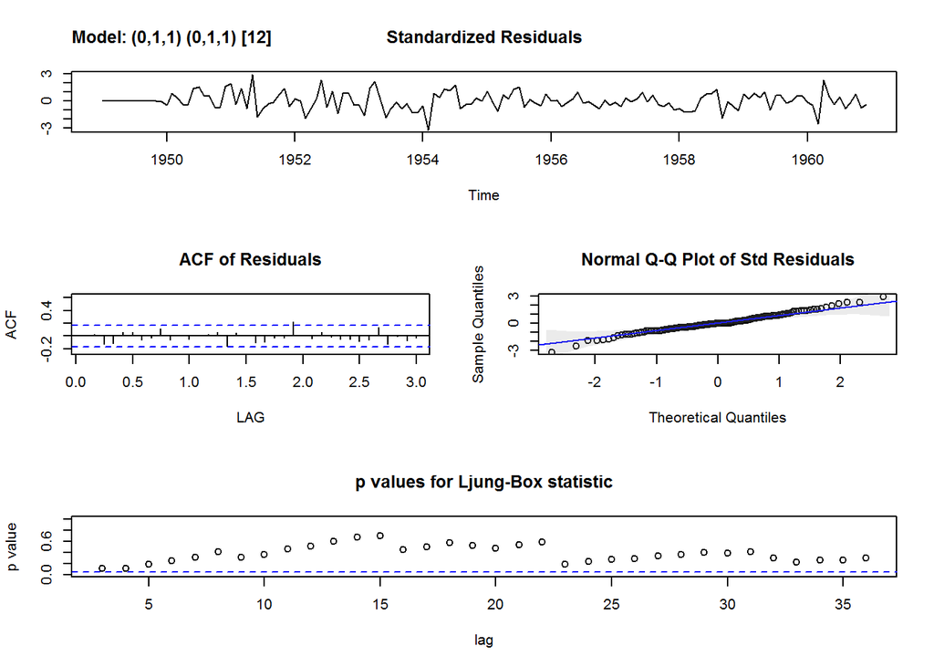

```r
airpass_fit2$ttable
```

```
     Estimate     SE t.value p.value
ma1   -0.4018 0.0896 -4.4825       0
sma1  -0.5569 0.0731 -7.6190       0
```

In the residual diagnostics shown for this model everything looks fine and it’s a fine good model.

### 16.2.4 Fit a Mixed Seasonal Model

Pure seasonal dependence such as that explored earlier in this chapter is relatively rare. Most seasonal time series have mixed dependence, meaning only some of the variation is explained by seasonal trends.

Recall that the full seasonal model is denoted by SARIMA(p,d,q)x(P,D,Q)$_S$ where capital letters denote the seasonal orders.

As before, this exercise asks you to compare the sample P/ACF pair to the true values for some simulated seasonal data and fit a model to the data using sarima(). This time, the simulated data come from a mixed seasonal model, SARIMA(0,0,1)x(0,0,1)12. The plots on the right show three years of data, as well as the model ACF and PACF. Notice that, as opposed to the pure seasonal model, there are correlations at the nonseasonal lags as well as the seasonal lags.

As always, the astsa package is preloaded. The generated data are in x.

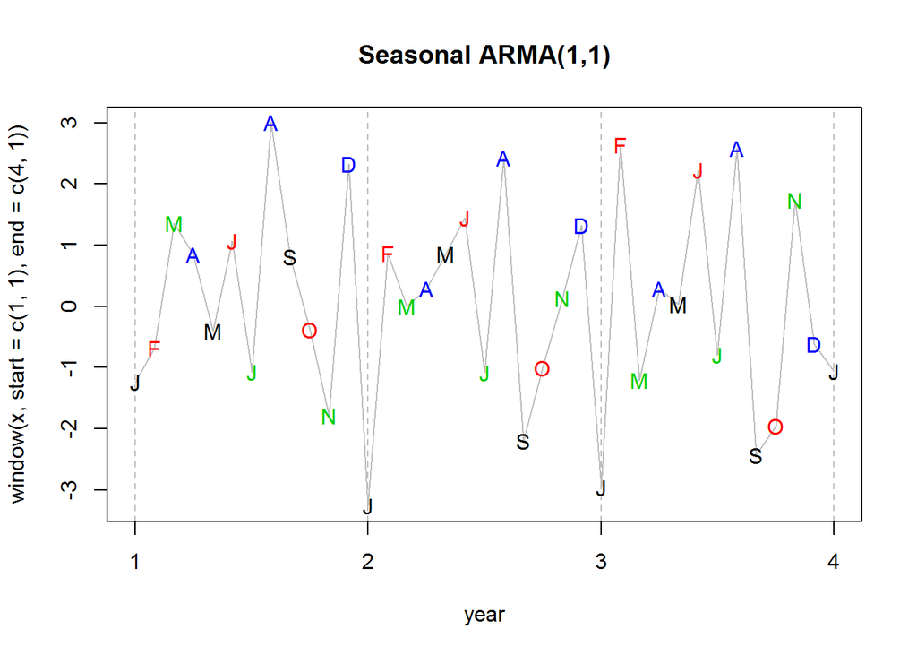

```r
Months <- c("J", "F", "M", "A", "M", "J", "J", "A", "S", "O", "N", "D")
plot(window(x, start=c(1,1), end=c(4,1)), type="l", col="gray", xaxt="n", xlab="year", main="Seasonal ARMA(1,1)")
abline(v=1:4, lty=2, col="gray")
points(window(x, start=c(1,1), end=c(4,1)), pch=Months, col=1:4)
axis(1, 1:4)
```

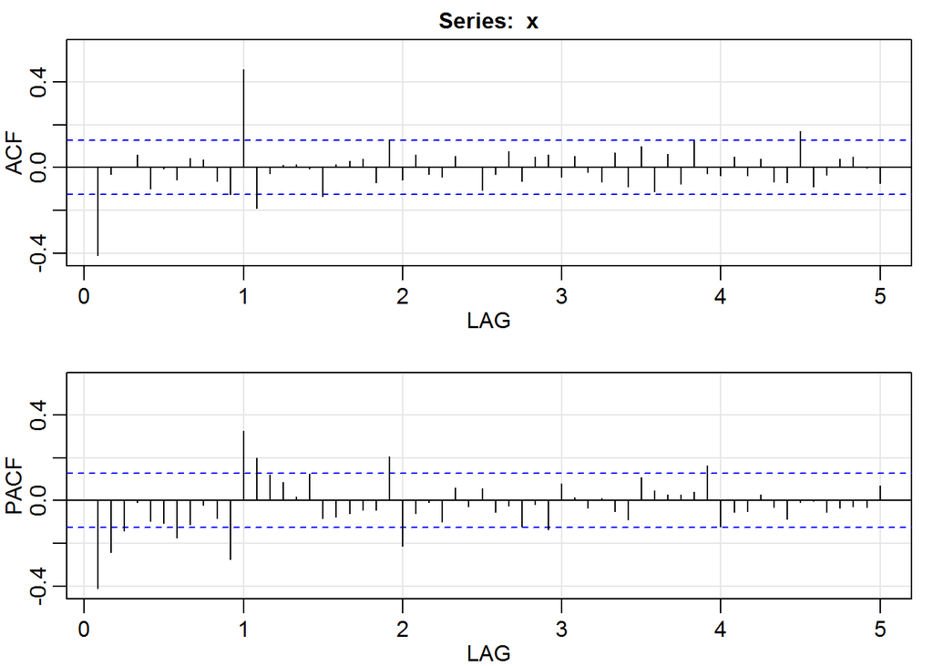

```r
invisible(acf2(x,max.lag = 60))
```

Fit the seasonal model to x

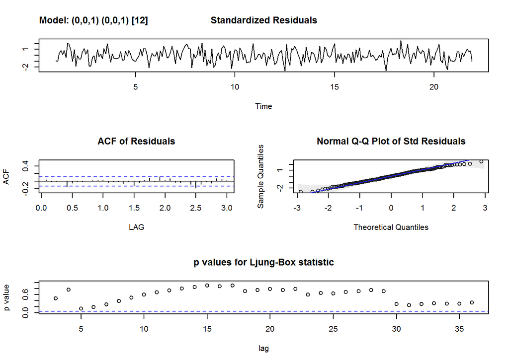

```
$fit

Call:
stats::arima(x = xdata, order = c(p, d, q), seasonal = list(order = c(P, D,
    Q), period = S), xreg = xmean, include.mean = FALSE, optim.control = list(trace = trc,
    REPORT = 1, reltol = tol))

Coefficients:
          ma1    sma1   xmean
      -0.6142  0.7888  0.0784
s.e.   0.0565  0.0475  0.0430

sigma^2 estimated as 1.005:  log likelihood = -364.26,  aic = 736.52

$degrees_of_freedom
[1] 249

$ttable
      Estimate     SE  t.value p.value
ma1    -0.6142 0.0565 -10.8809  0.0000
sma1    0.7888 0.0475  16.6094  0.0000
xmean   0.0784 0.0430   1.8253  0.0692

$AIC
[1] 1.028672

$AICc
[1] 1.037251

$BIC
[1] 0.07068873
```

```r
sarima(x, p = 0, d = 0, q = 1, P = 0, D = 0, Q = 1, S = 12)
```

Time series data collected on a seasonal basis typcially have mixed dependence. For example, what happens in June is often related to what happend in May as well as what happened in June of last year.

### 16.2.5 Data Analysis - Unemployment I

Plot the monthly US unemployment (unemp) time series from astsa. Note trend and seasonality.

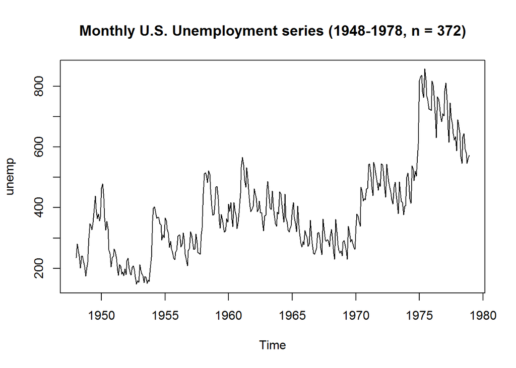

```r
plot(unemp, main="Monthly U.S. Unemployment series (1948-1978, n = 372)")
```

Detrend and plot the data. Save this as d_unemp. Notice the seasonal persistence. The log was not applied because data doesn’t show heteroskedasticity.

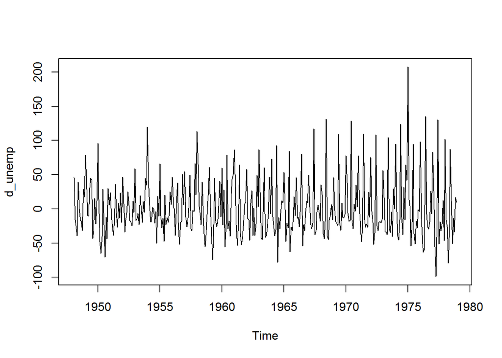

```r
d_unemp <- diff(unemp)
plot(d_unemp)
```

Seasonally difference the detrended series and save this as dd_unemp. Plot this new data and notice that it looks stationary now.

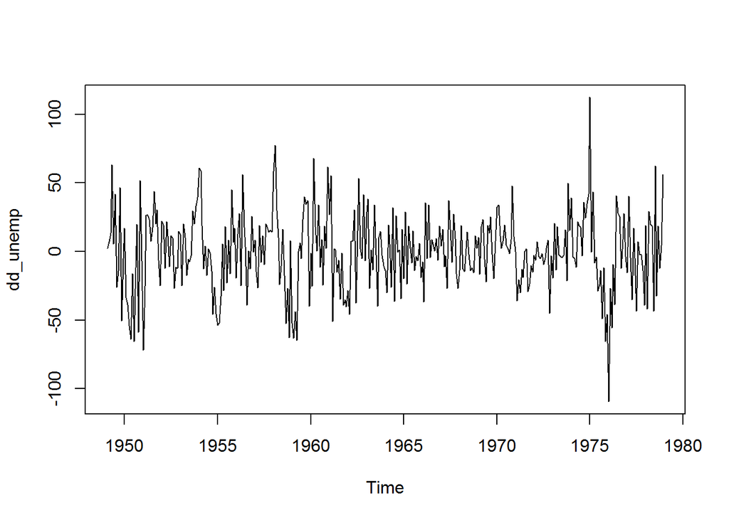

```r
dd_unemp <- diff(d_unemp, lag = 12)
plot(dd_unemp)
```

### 16.2.6 Data Analysis - Unemployment II

Difference the data fully (as in the previous exercise) and plot the sample ACF and PACF of the transformed data to lag 60 months (5 years).

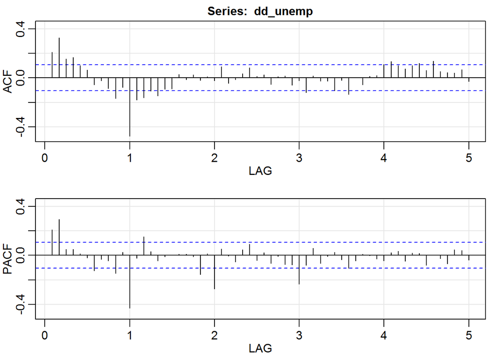

```r
dd_unemp <- diff(diff(unemp), lag = 12)
invisible(acf2(dd_unemp, max.lag = 60))
```

Consider that, for:

- the nonseasonal component: the PACF cuts off at lag 2 and the ACF tails off.

Suggest and fit a model using sarima(). Check the residuals to ensure appropriate model fit.

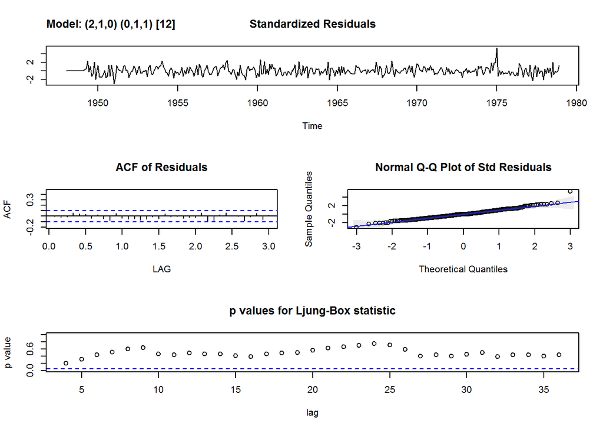

```
$fit

Call:
stats::arima(x = xdata, order = c(p, d, q), seasonal = list(order = c(P, D,
    Q), period = S), include.mean = !no.constant, optim.control = list(trace = trc,
    REPORT = 1, reltol = tol))

Coefficients:
         ar1     ar2     sma1
      0.1351  0.2464  -0.6953
s.e.  0.0513  0.0515   0.0381

sigma^2 estimated as 449.6:  log likelihood = -1609.91,  aic = 3227.81

$degrees_of_freedom
[1] 356

$ttable
     Estimate     SE  t.value p.value
ar1    0.1351 0.0513   2.6326  0.0088
ar2    0.2464 0.0515   4.7795  0.0000
sma1  -0.6953 0.0381 -18.2362  0.0000

$AIC
[1] 7.12457

$AICc
[1] 7.130239

$BIC
[1] 6.156174
```

```r
sarima(unemp, p = 2, d = 1, q = 0, P = 0, D = 1, Q = 1, S = 12)
```

### 16.2.7 Data Analysis - Commodity Prices: Chicken

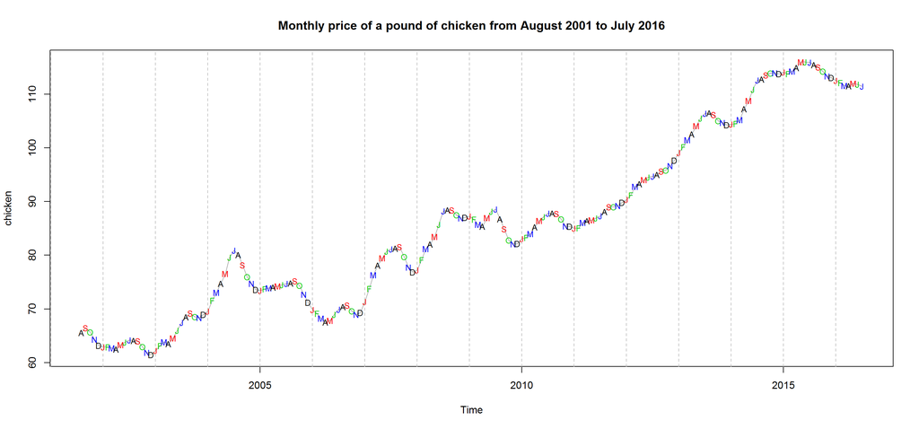

```r
Months <- c("A", "S", "O", "N", "D", "J", "F", "M", "A", "M", "J", "J")
plot(chicken, col="dark grey", main="Monthly price of a pound of chicken from August 2001 to July 2016")
points(chicken, pch=Months, col=1:4, cex=.8)
abline(v=seq(from=2001, to=2016), lty=2, col="gray")
```

Removing trend and noticing some mixed seasonal behaviour

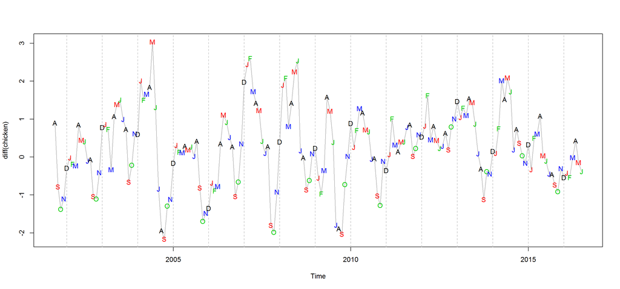

```r
plot(diff(chicken), col="dark grey")
points(diff(chicken), pch=Months, col=1:4)
abline(v=seq(from=2001, to=2016), lty=2, col="gray")
```

Plot the sample ACF and PACF of the differenced data to lag 60 (5 years). After removing the trend, the sample ACF and PACF suggest an AR(2) model because the PACF cuts off after lag 2 and the ACF tails off. However, the ACF has a small seasonal component remaining. This can be taken care of by fitting an addition SAR(1) component.

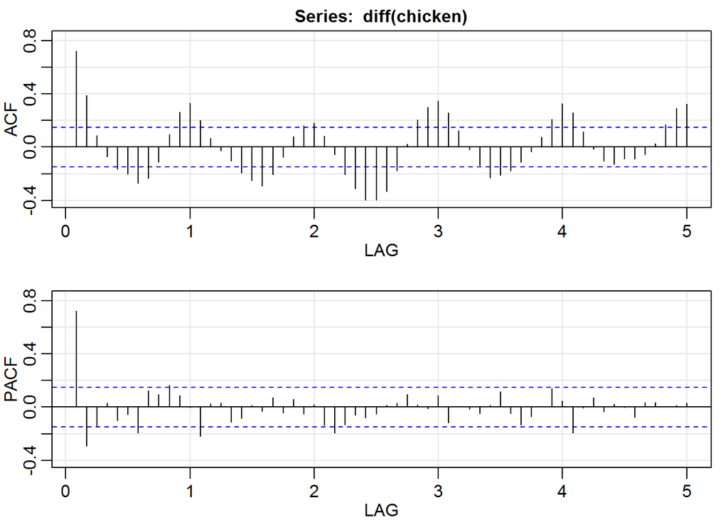

```r
invisible(acf2(diff(chicken), max.lag=60))
```

Fit ARIMA(2,1,0) to chicken - not so good

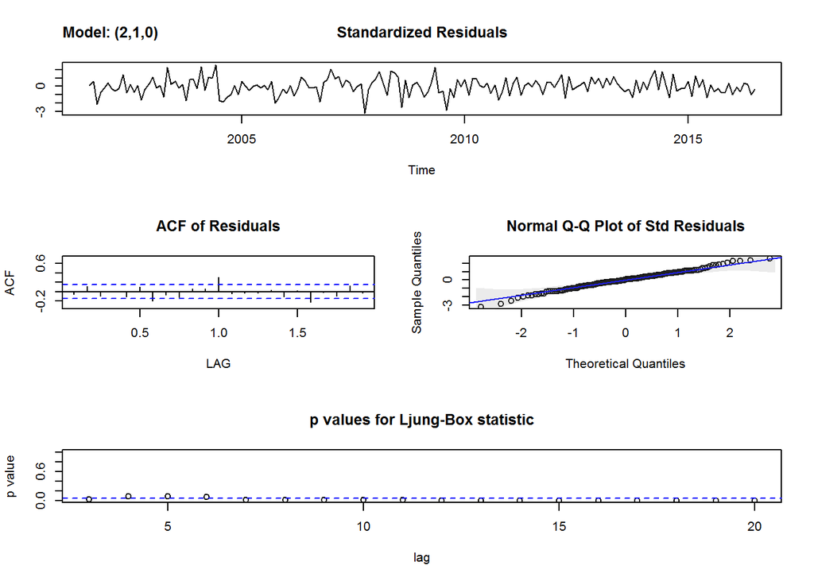

```
$fit

Call:
stats::arima(x = xdata, order = c(p, d, q), seasonal = list(order = c(P, D,
    Q), period = S), xreg = constant, optim.control = list(trace = trc, REPORT = 1,
    reltol = tol))

Coefficients:
         ar1      ar2  constant
      0.9494  -0.3069    0.2632
s.e.  0.0717   0.0718    0.1362

sigma^2 estimated as 0.4286:  log likelihood = -178.64,  aic = 365.28

$degrees_of_freedom
[1] 176

$ttable
         Estimate     SE t.value p.value
ar1        0.9494 0.0717 13.2339  0.0000
ar2       -0.3069 0.0718 -4.2723  0.0000
constant   0.2632 0.1362  1.9328  0.0549

$AIC
[1] 0.1861622

$AICc
[1] 0.1985432

$BIC
[1] -0.7606218
```

```r
sarima(chicken, 2,1,0)
```

Fit SARIMA(2,1,0,1,0,0,12) to chicken - that works

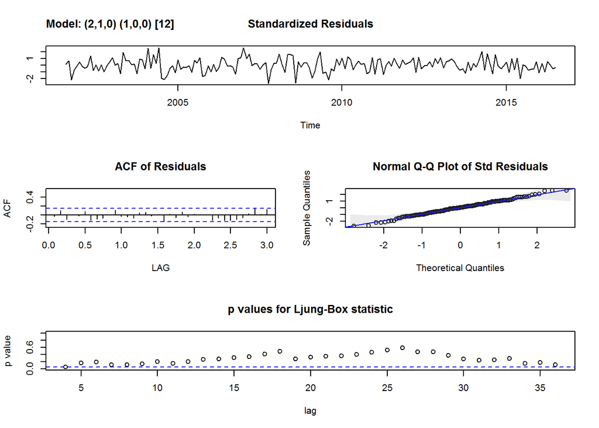

```
$fit

Call:
stats::arima(x = xdata, order = c(p, d, q), seasonal = list(order = c(P, D,
    Q), period = S), xreg = constant, optim.control = list(trace = trc, REPORT = 1,
    reltol = tol))

Coefficients:
         ar1      ar2    sar1  constant
      0.9154  -0.2494  0.3237    0.2353
s.e.  0.0733   0.0739  0.0715    0.1973

sigma^2 estimated as 0.3828:  log likelihood = -169.16,  aic = 348.33

$degrees_of_freedom
[1] 175

$ttable
         Estimate     SE t.value p.value
ar1        0.9154 0.0733 12.4955  0.0000
ar2       -0.2494 0.0739 -3.3728  0.0009
sar1       0.3237 0.0715  4.5238  0.0000
constant   0.2353 0.1973  1.1923  0.2347

$AIC
[1] 0.0842377

$AICc
[1] 0.09726452

$BIC
[1] -0.8448077
```

```r
sarima(chicken, 2,1,0,1,0,0,12)
```

### 16.2.8 Data Analysis - Birth Rate

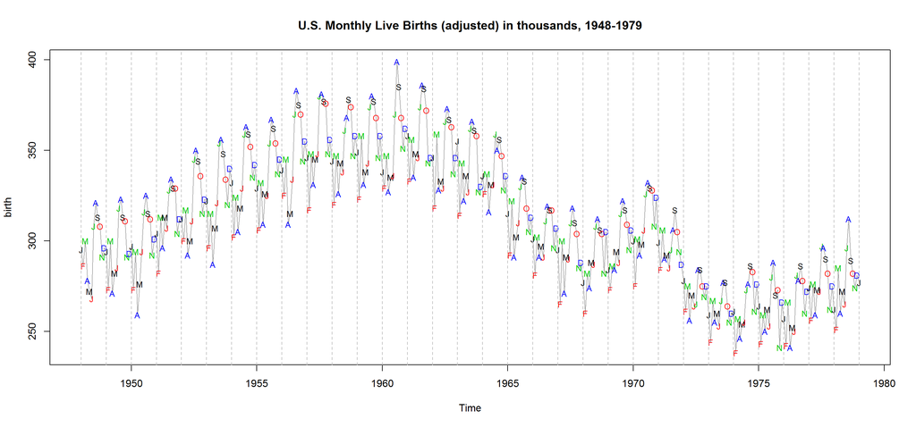

```r
Months <- c("J", "F", "M", "A", "M", "J", "J", "A", "S", "O", "N", "D")
plot(birth, col="dark grey", main="U.S. Monthly Live Births (adjusted) in thousands, 1948-1979")
points(birth, pch=Months, col=1:4, cex=.8)
abline(v=seq(from=1948, to=1979), lty=2, col="gray")
```

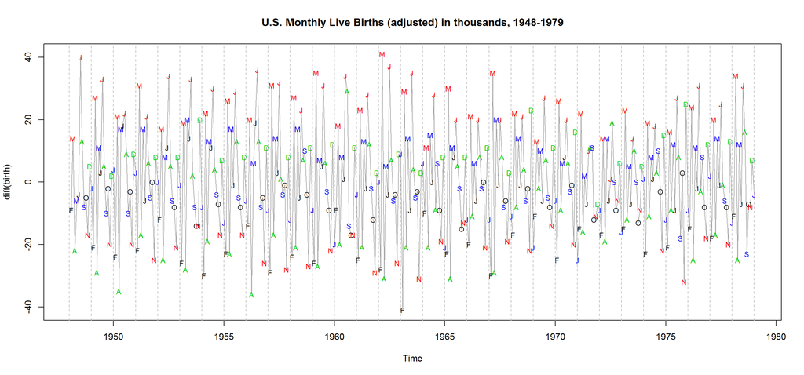

```r
Months <- c("F", "M", "A", "M", "J", "J", "A", "S", "O", "N", "D", "J")
plot(diff(birth), col="dark grey", main="U.S. Monthly Live Births (adjusted) in thousands, 1948-1979")
points(diff(birth), pch=Months, col=1:4, cex=.8)
abline(v=seq(from=1948, to=1979), lty=2, col="gray")
```

Plot the sample ACF and PACF of the differenced data to lag 60 (5 years). Notice the seasonal persistence at ACF. This requires to take the 12-month seasonal difference from the differenced data.

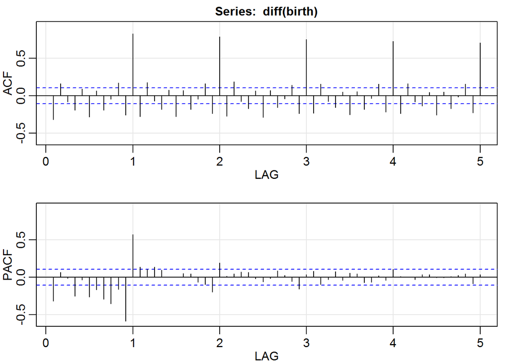

```r
invisible(acf2(diff(birth), max.lag=60))
```

Taking the 12-month seasonal difference from the differenced data

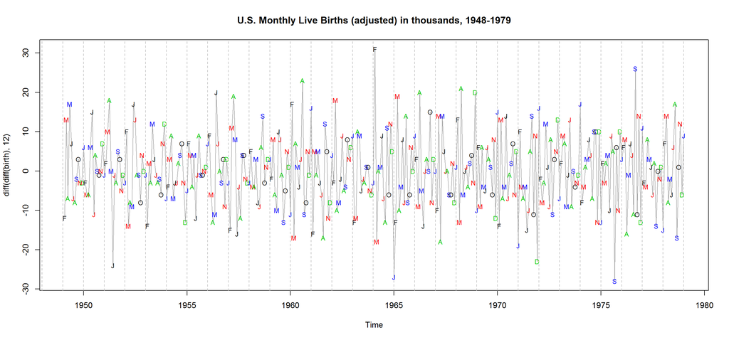

```r
Months <- c("F", "M", "A", "M", "J", "J", "A", "S", "O", "N", "D", "J")
plot(diff(diff(birth), 12), col="dark grey", main="U.S. Monthly Live Births (adjusted) in thousands, 1948-1979")
points(diff(diff(birth), 12), pch=Months, col=1:4, cex=.8)
abline(v=seq(from=1948, to=1979), lty=2, col="gray")
```

Plot P/ACF to lag 60 of seasonal differenced data.

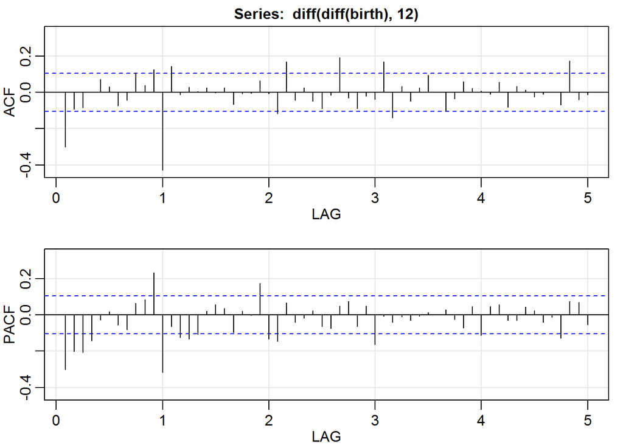

```r
invisible(acf2(diff(diff(birth),12), max.lag=60))
```

- Seasonal component: SMA(1)
  - ACF cuts off at lag Q=1
  - PACF tails off
- Non-Seasonal component: MA(1)
  - ACF cuts off at lag q=1
  - PACF tails off

Conclude that an SARIMA(0,1,1)x(0,1,1)12 model seems reasonable.

Fitting SARIMA(0,1,1)x(0,1,1)$_{12}$ shows that all p-values are bellow the limit, confirming it there’s still correlation in the residuals so the are not white noise and this is not a good model fit.

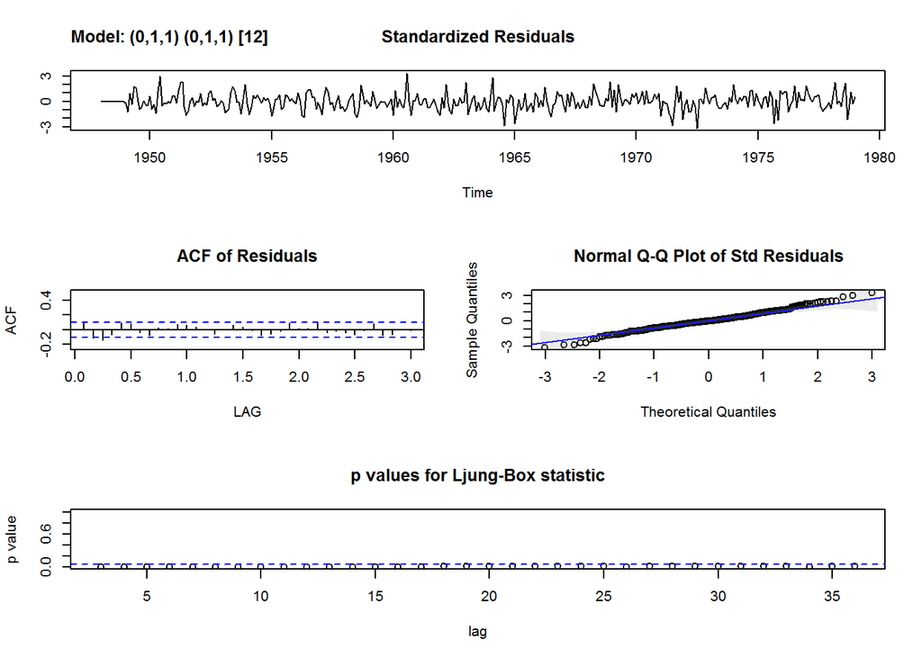

```
$fit

Call:
stats::arima(x = xdata, order = c(p, d, q), seasonal = list(order = c(P, D,
    Q), period = S), include.mean = !no.constant, optim.control = list(trace = trc,
    REPORT = 1, reltol = tol))

Coefficients:
          ma1     sma1
      -0.4734  -0.7861
s.e.   0.0598   0.0451

sigma^2 estimated as 47.4:  log likelihood = -1211.28,  aic = 2428.56

$degrees_of_freedom
[1] 358

$ttable
     Estimate     SE  t.value p.value
ma1   -0.4734 0.0598  -7.9097       0
sma1  -0.7861 0.0451 -17.4227       0

$AIC
[1] 4.869388

$AICc
[1] 4.874924

$BIC
[1] 3.890415
```

```r
sarima(birth, 0,1,1, 0,1,1, 12)
```

Adding and AR(1) term fitted a good model

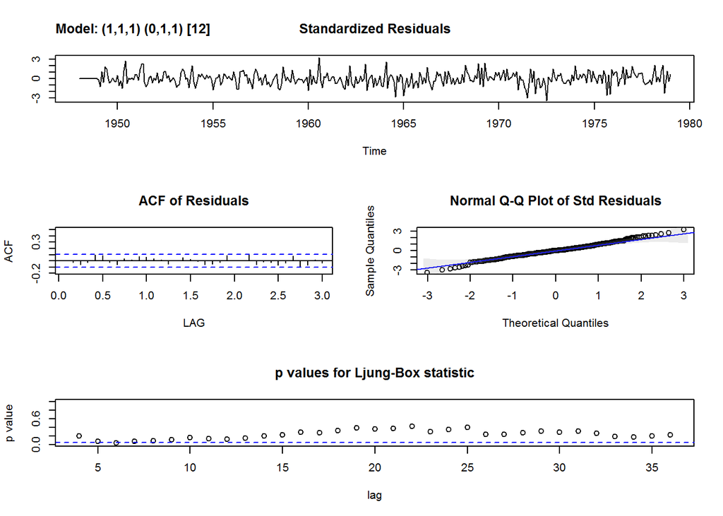

```
$fit

Call:
stats::arima(x = xdata, order = c(p, d, q), seasonal = list(order = c(P, D,
    Q), period = S), include.mean = !no.constant, optim.control = list(trace = trc,
    REPORT = 1, reltol = tol))

Coefficients:
         ar1      ma1     sma1
      0.3038  -0.7006  -0.8000
s.e.  0.0865   0.0604   0.0441

sigma^2 estimated as 45.91:  log likelihood = -1205.93,  aic = 2419.85

$degrees_of_freedom
[1] 357

$ttable
     Estimate     SE  t.value p.value
ar1    0.3038 0.0865   3.5104   5e-04
ma1   -0.7006 0.0604 -11.5984   0e+00
sma1  -0.8000 0.0441 -18.1302   0e+00

$AIC
[1] 4.842869

$AICc
[1] 4.848523

$BIC
[1] 3.87441
```

```r
sarima(birth, 1,1,1, 0,1,1, 12)
```

The residual analysis from the first fit indicated that the residuals were not white noise. Hence, it was necessary to include an additional nonseasonal AR term to account for the extra correlation.

## 16.3 Forecasting Seasonal ARIMA

Forecasting ARIMA Processes

- Once model is chosen, forecasting is easy because the model describes how the dynamics of the time series behave over time
- Simply continue the model dynamics into the future
- In the astsa package, use sarima.for() for forecasting

### 16.3.1 Forecasting Air Passengers

- In the previous video, we decided that a SARIMA(0,1,1)x(0,1,1)12 model was appropriate

The grayt swatches represent the 1 and 2 Root Mean Squared prediction intervals.

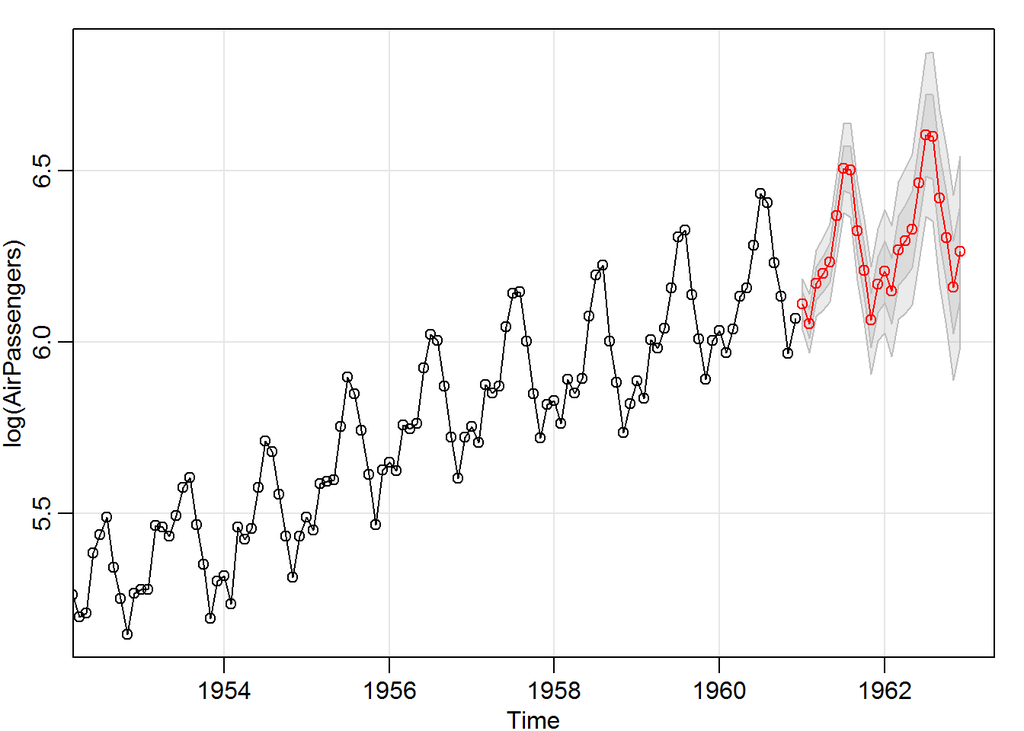

```r
invisible(sarima.for(log(AirPassengers), n.ahead = 24, 0, 1, 1, 0, 1, 1, 12))
```

### 16.3.2 Forecasting Monthly Unemployment

Previously, you fit an SARIMA(2,1,0, 0,1,1)12 model to the monthly US unemployment time series unemp. You will now use that model to forecast the data 3 years.

Fit your previous model to unemp and check the diagnostics.

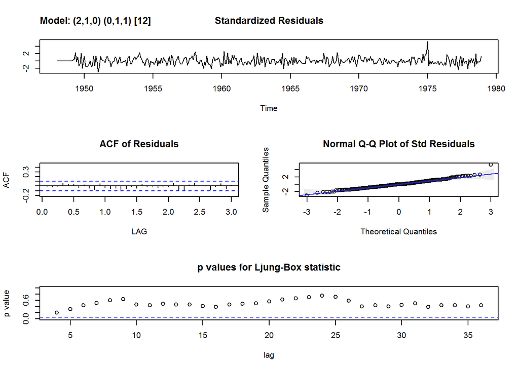

```
$fit

Call:
stats::arima(x = xdata, order = c(p, d, q), seasonal = list(order = c(P, D,
    Q), period = S), include.mean = !no.constant, optim.control = list(trace = trc,
    REPORT = 1, reltol = tol))

Coefficients:
         ar1     ar2     sma1
      0.1351  0.2464  -0.6953
s.e.  0.0513  0.0515   0.0381

sigma^2 estimated as 449.6:  log likelihood = -1609.91,  aic = 3227.81

$degrees_of_freedom
[1] 356

$ttable
     Estimate     SE  t.value p.value
ar1    0.1351 0.0513   2.6326  0.0088
ar2    0.2464 0.0515   4.7795  0.0000
sma1  -0.6953 0.0381 -18.2362  0.0000

$AIC
[1] 7.12457

$AICc
[1] 7.130239

$BIC
[1] 6.156174
```

```r
sarima(unemp, 2,1,0, 0,1,1, 12)
```

Forecast the data 3 years into the future

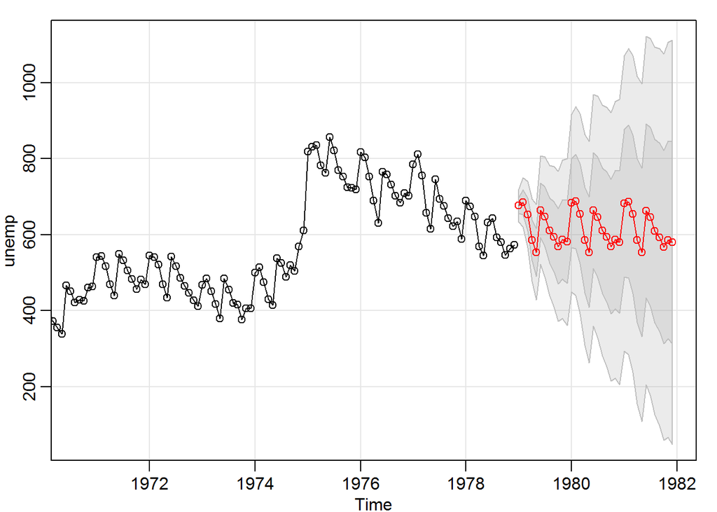

```
$pred
          Jan      Feb      Mar      Apr      May      Jun      Jul      Aug      Sep      Oct
1979 676.4664 685.1172 653.2388 585.6939 553.8813 664.4072 647.0657 611.0828 594.6414 569.3997
1980 683.3045 687.7649 654.8658 586.1507 553.9285 664.1108 646.6220 610.5345 594.0427 568.7684
1981 682.6406 687.0977 654.1968 585.4806 553.2579 663.4398 645.9508 609.8632 593.3713 568.0970
          Nov      Dec
1979 587.5801 581.1833
1980 586.9320 580.5249
1981 586.2606 579.8535

$se
           Jan       Feb       Mar       Apr       May       Jun       Jul       Aug       Sep
1979  21.20465  32.07710  43.70167  53.66329  62.85364  71.12881  78.73590  85.75096  92.28663
1980 116.99599 124.17344 131.51281 138.60466 145.49706 152.12863 158.52302 164.68623 170.63839
1981 194.25167 201.10648 208.17066 215.11503 221.96039 228.64285 235.16874 241.53258 247.74268
           Oct       Nov       Dec
1979  98.41329 104.19488 109.67935
1980 176.39520 181.97333 187.38718
1981 253.80549 259.72970 265.52323
```

```r
sarima.for(unemp, n.ahead = 36, 2,1,0,0,1,1,12)
```

The forecast is able to replicate much of the seasonal variation in the original unemployment data.

### 16.3.3 How Hard is it to Forecast Commodity Prices?

As previously mentioned, making money in commodities is not easy. To see a difficulty in predicting a commodity, you will forecast the price of chicken to five years in the future. When you complete your forecasts, you will note that even just a few years out, the acceptable range of prices is very large. This is because commodities are subject to many sources of variation.

Recall that you previously fit an SARIMA(2,1,0, 1,0,0)12 model to the monthly US chicken price series chicken. You will use this model to calculate your forecasts.

Fit the chicken model again and check diagnostics

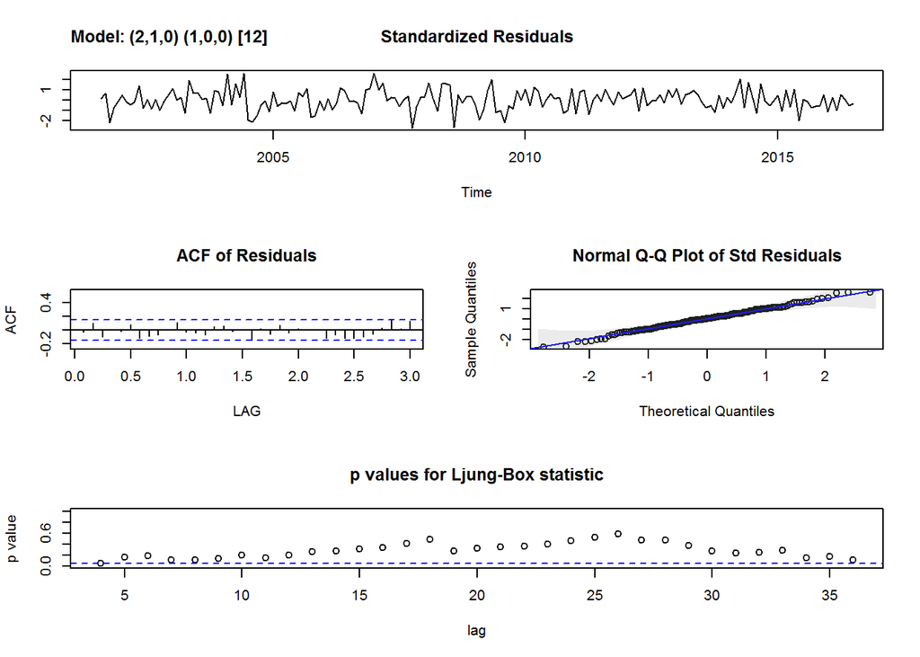

```
$fit

Call:
stats::arima(x = xdata, order = c(p, d, q), seasonal = list(order = c(P, D,
    Q), period = S), xreg = constant, optim.control = list(trace = trc, REPORT = 1,
    reltol = tol))

Coefficients:
         ar1      ar2    sar1  constant
      0.9154  -0.2494  0.3237    0.2353
s.e.  0.0733   0.0739  0.0715    0.1973

sigma^2 estimated as 0.3828:  log likelihood = -169.16,  aic = 348.33

$degrees_of_freedom
[1] 175

$ttable
         Estimate     SE t.value p.value
ar1        0.9154 0.0733 12.4955  0.0000
ar2       -0.2494 0.0739 -3.3728  0.0009
sar1       0.3237 0.0715  4.5238  0.0000
constant   0.2353 0.1973  1.1923  0.2347

$AIC
[1] 0.0842377

$AICc
[1] 0.09726452

$BIC
[1] -0.8448077
```

```r
sarima(chicken, 2,1,0, 1,0,0, 12)
```

Forecast the chicken data 5 years into the future

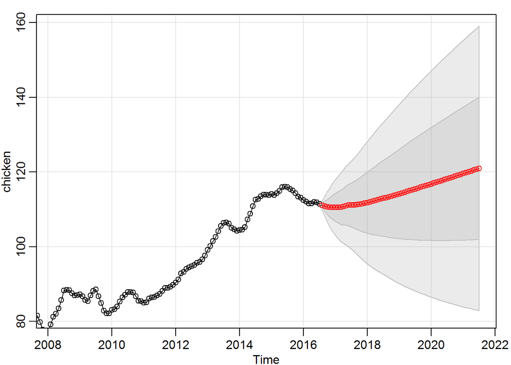

```
$pred
          Jan      Feb      Mar      Apr      May      Jun      Jul      Aug      Sep      Oct
2016                                                                111.0907 110.8740 110.6853
2017 110.5358 110.5612 110.5480 110.7055 111.0047 111.1189 111.1552 111.1948 111.2838 111.3819
2018 111.8108 111.9782 112.1330 112.3431 112.5991 112.7952 112.9661 113.1380 113.3260 113.5168
2019 114.1331 114.3464 114.5556 114.7827 115.0247 115.2473 115.4617 115.6765 115.8965 116.1174
2020 116.7942 117.0224 117.2492 117.4819 117.7193 117.9505 118.1790 118.4077 118.6380 118.8686
2021 119.5651 119.7980 120.0306 120.2650 120.5010 120.7350 120.9681
          Nov      Dec
2016 110.5045 110.5527
2017 111.4825 111.6572
2018 113.7085 113.9242
2019 116.3386 116.5675
2020 119.0993 119.3326
2021
```

[output cut: 16 more lines]

```r
sarima.for(chicken, n.ahead=60, 2,1,0, 1,0,0, 12)
```

# 17 What you’ve learned

- How to identify an ARMA model from data looking at ACF and PACF
- How to use integrated ARMA (ARIMA) models for nonstationary time series
- How to cope with seasonality